# Data Cleaning

#### Description

This document describes how to ready your expression data for an EVE analysis. For this process, we will use the expression data and phylogenies included in the `data` folder. Importantly, the data consists of singleton and duplicate genes, and consequently, part of the cleaning process will involve transforming the data such that paired duplicate genes are represented in one row. For the purpose of saving time, some of the objects throughout the scripts have been preloaded in the `tutorial.RData` file.

#### Instructions

```r
salmonids <- c("Ssal", "Omyk", "Okis", "Salp", "Hhuc", "Tthy")
outgroup <- c("Drer", "Olat", "Gacu", "Eluc", "Nhub", "Upyg")
```

Read in trees and remove irrelevant species

```r
single_tree <- read.tree("../data/SpeciesTree_rooted_node_labels.txt")
single_tree <- keep.tip(single_tree, single_tree$tip.label[-c(1:2)])
dup_tree <- read.tree("../data/SpeciesTree_rooted_node_labels_duplicated.txt") # duplicated
dup_tree <- keep.tip(dup_tree, dup_tree$tip.label[-c(1:2)])
```

Singleton tree

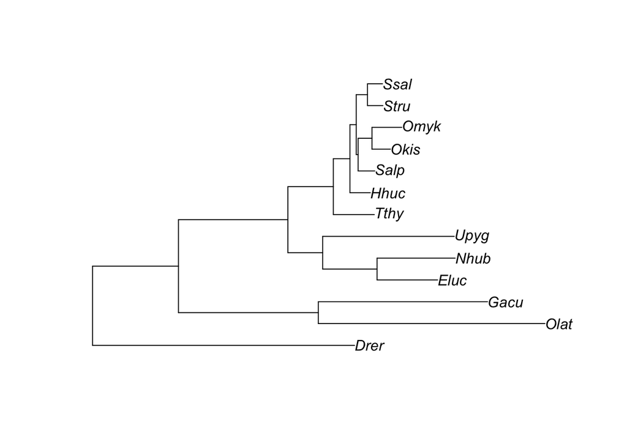

```r
plot(single_tree)
```

Duplicate tree

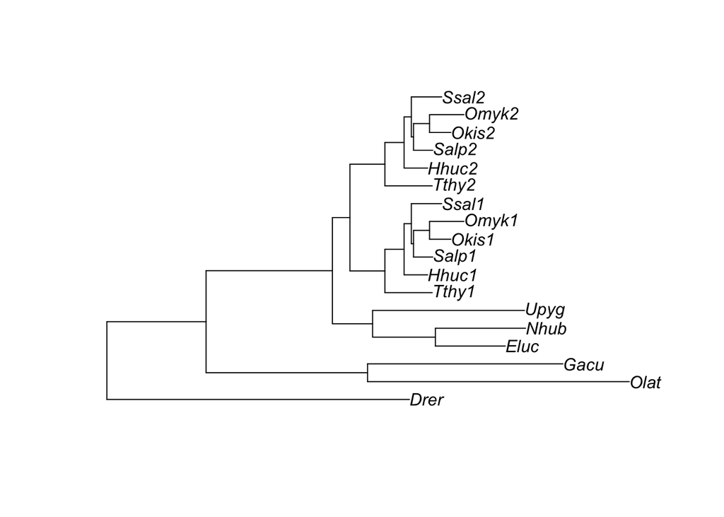

```r
plot(dup_tree)
```

Load in tissue TPM data

```r
brain <- readRDS("../data/combExprMat_Br.RDS") %>% as.data.frame()
gills <- readRDS("../data/combExprMat_Gi.RDS") %>% as.data.frame()
liver <- readRDS("../data/combExprMat_Li.RDS") %>% as.data.frame()
spleen <- readRDS("../data/combExprMat_Sp.RDS") %>% as.data.frame()
```

N2 to N7 geneID table (clade geneID translation)

```r
N7geneIDtbl <- readRDS("../data/N7geneIDtbl.RDS")
```

Remove genes with little to no expression

```r
removeGenes <- function(data) {
  salmonidCols = colnames(data) %in% salmonids
  # Note that log2(0.01) means no expression, i.e. TPM=0
  exprCheckTbl <- tibble(N7 = rownames(data), salmidHasExpr = rowMeans(data[,salmonidCols] > log2(0.01)) > 0.5,
                         outHasExpr = rowMeans(data[,!salmonidCols] > log2(0.01)) > 0.5,
                         hasVar = apply(data, 1, var) > 0) %>% # For each N2, check that all salmonid clades and out-group has the                               minimum expression
                  left_join(dplyr::select(N7geneIDtbl,N2,N7,dup_type), by="N7") %>%
                  group_by(N2) %>%
                  mutate( allExpr = all(salmidHasExpr) & outHasExpr, allVar = any(hasVar)) %>%
                  ungroup()

data_filtered <- data[filter(exprCheckTbl, allExpr == T, allVar == T)$N7,]

return(data_filtered)
}

brain_filt <- removeGenes(brain)
gills_filt <- removeGenes(gills)
liver_filt <- removeGenes(liver)
spleen_filt <- removeGenes(spleen)
```

Only include shared genes among all tissues

```r
sharedGenes <- Reduce(intersect, lapply(list(brain_filt, gills_filt,liver_filt, spleen_filt), rownames))
brain_clean <- brain_filt[rownames(brain_filt) %in% sharedGenes,]
gills_clean <- gills_filt[rownames(gills_filt) %in% sharedGenes,]
liver_clean <- liver_filt[rownames(liver_filt) %in% sharedGenes,]
spleen_clean <- spleen_filt[rownames(spleen_filt) %in% sharedGenes,]
```

Split geneID table by duplicate and singleton genes

```r
single_tbl <- N7geneIDtbl %>% filter(dup_type == "single")
dup_tbl <- N7geneIDtbl %>% filter(dup_type == "duplicate")
```

Split tissue TPM data by singleton and duplicate genes

```r
brain_single <- brain_clean[rownames(brain_clean) %in% single_tbl$N7,]
gills_single <- gills_clean[rownames(gills_clean) %in% single_tbl$N7,]
liver_single <- liver_clean[rownames(liver_clean) %in% single_tbl$N7,]
spleen_single <- spleen_clean[rownames(spleen_clean) %in% single_tbl$N7,]

brain_dup <- brain_clean[rownames(brain_clean) %in% dup_tbl$N7,]
gills_dup <- gills_clean[rownames(gills_clean) %in% dup_tbl$N7,]
liver_dup <- liver_clean[rownames(liver_clean) %in% dup_tbl$N7,]
spleen_dup <- spleen_clean[rownames(spleen_clean) %in% dup_tbl$N7,]
```

Find duplicate N7 pairs

```r
N2_dups <- unique(dup_tbl$N2)
N7_pairs <- NULL
for(dup in N2_dups) {
  pair <- dup_tbl %>%
    filter(N2 == dup) %>%
    dplyr::select(N7)
  N7_pairs <- rbind(N7_pairs, pair$N7)
}
N7_pairs <- as.data.frame(N7_pairs)
names(N7_pairs) <- c("Key","Pair")
```

Transform the duplicated TPM data to include paired duplicates in one row

```r
dupTransform <- function(gene.data) {
  # function definition for returning second copy, given first copy
  keyPair <- function(data, key) {
    pair = data %>%
      filter(Key == key) %>%
      dplyr::select(Pair)
    return(as.vector(pair[[1]]))
  }

  copy <- as.data.frame(gene.data) # copying data for safety
  names <- colnames(copy)
  salmonIndex <- colnames(copy) %in% salmonids %>% which()
  outgroupIndex <- colnames(copy) %in% outgroup %>% which()
  colnames(copy) %<>% replace(salmonIndex, paste(.[salmonIndex], "1", sep="")) # rename original salmonid clade ("Ssal" is now "Ssal1")

  # set up duplicate salmonid clade
  dupClade <- paste(names[salmonIndex], "2", sep="") # names for dup clade ("Ssal2"...)
  names <- c(colnames(copy), dupClade)
  dupCladeIndex <- names %in% dupClade %>% which() # indices for dup clade
  copy[,dupClade] <- NA # create columns for duplicate clade
  colnames(copy) <- names

  for (rowName in rownames(copy)) {
    # duplicated gene, first copy
    if(rowName %in% N7_pairs$Key == TRUE) {
      pairName <- keyPair(N7_pairs,rowName) # find second copy of duplicated gene

      # make sure outgroup values are the same between copies; otherwise throws an error
      stopifnot(copy[rowName, outgroupIndex] == copy[pairName, outgroupIndex])

      copy[rowName, dupCladeIndex] <- copy[pairName, salmonIndex] # fill in duplicate clade with pair values
      copy <- copy[!rownames(copy) %in% pairName, ] # delete duplicated gene's second copy
    }
  }

  return(copy)
}

brain_dup %<>% dupTransform
gills_dup %<>% dupTransform
liver_dup %<>% dupTransform
spleen_dup %<>% dupTransform
```

For notebook keeping, store all single and duplicate gene names separately

```r
genes.single <- rownames(brain_single) %>%
  data.frame(N7 = .) %>%
  left_join(., N7geneIDtbl, by = "N7") %>%
  dplyr::select(N7, Ssal)
genes.dup <- rownames(brain_dup) %>%
  data.frame(N7 = .) %>%
  left_join(., N7geneIDtbl, by = "N7") %>%
  dplyr::select(N7, Ssal)
genes.all <- rbind(genes.single, genes.dup)
```